# 文字探勘

2017/6/17

## 探勘動機

使用者在填寫交友軟體報名表時，能夠不限格式的輸入自我介紹以及想要聊天的主題，根據筆者的觀察，使用者的自我介紹和想要聊天的主題通常都是息息相關的，藉此我以不區分的方式，直接進行中文探勘，希望能夠了解使用者對於哪些事情最感興趣，大概都是哪些類型的人喜歡使用此交友軟體來認識朋友。

## 資料原始型態

```
##  [1] profile topic
##  [2] 1 我是Eatgether這個服務的創辦人，你好，因為我自己也很好奇我會被系統配到誰，如果剛好是你的話，很高興認識妳，賭賭看我們有多高的機率見面呢？（笑） 創業、設計、音樂、寵物、電音、搖滾、網路、投資、旅遊
##  [3] 2 安安你好,我叫馬嘎,很高興認識你,希望我們可以有個很high的夜晚 (請勿幫我配大學生喔啾咪) 旅行/冒險/工作/夢想
##  [4] 3
##  [5] 4
##  [6] 5 3 2
##  [7] 6 一起喝杯咖啡吧 生活、音樂、設計、文藝
##  [8] 7 也需要酒伴阿.....唉唉 上至外太空 下至內...咳咳....行天宮
##  [9] 8
## [10] 9 安安你好我最近住在論文地獄裡的兔ㄐ 阿宅的東、文青的西
## 8616 Levels: \n6176 人生無設限！努力追求夢想～ 都可喔！開心就好\n6177 嗨，我喜歡運動，很高興認識你:-) 運動\n6178 水瓶座 玩具、扭蛋\n6179 喜歡美食、音樂，曾受邀、出。 音樂/桌遊/攝影/室內設計/烘培\n6180 創業中，平常也會開團帶大家去玩 人生、未來，興趣\n6181 建築師，大學教師 什麼都可以\n6182 27，嘉義人，雲林工作穩定 生涯規劃\n6183 做喜歡的事讓，喜歡的事有價值！ 美食、旅遊、人生、夢想\n6184 我是個短髮女生外表常給人很難接近酷酷，但其實我很健談，也可以很多話，除非是我沒興趣的談話 工作，興趣，旅遊\n6…
```

## 探勘原理

首先我們要先將標點符號、英文數字、空格等字元屏蔽掉，接下來則進入中文斷詞，分別根據名詞、動詞、形容詞做個別的儲存，在此選擇兩個字以上的詞才列入統計範圍內，例如："書"則不會被計入，但"書籍"則會被計入，接下來則將統計結果做成文字雲，文字愈大的詞則代表在此資料中出現最多次，以此類推。

## 文字雲

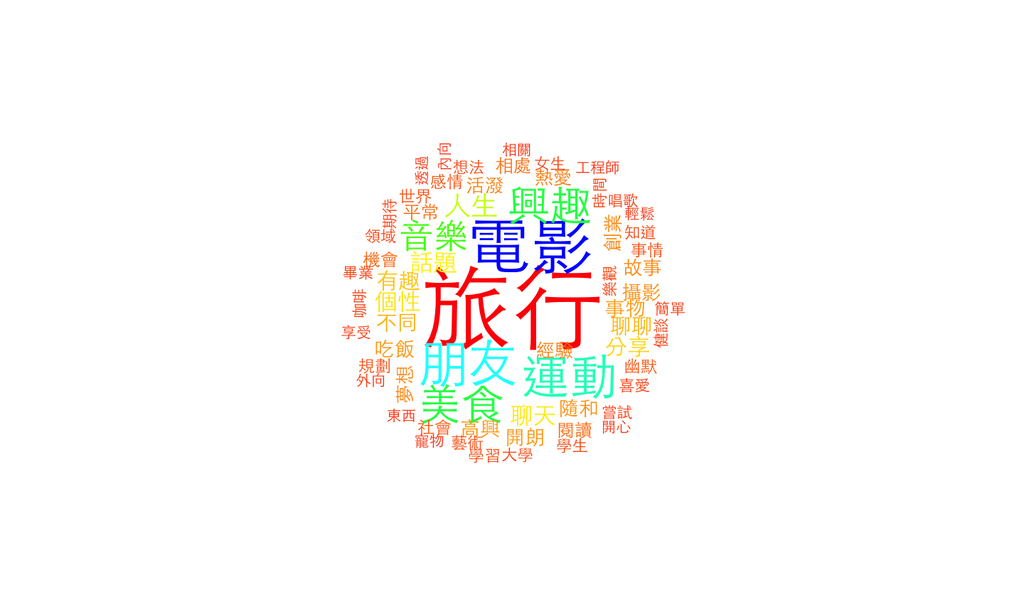

## 結論

可以明確地看出前三大主軸分別為1.旅行2.電影3.運動，再者則是美食、音樂、興趣等，具備豐富的旅行經驗，充沛的電影知識，健康的運動習慣，似乎已經是現代人必備的條件之一，所有人或多或少都擁有其中一項，這也間接的說明，若是想要與陌生人展開一個全新的話題，從這三項開始著手成功率應該最為顯著。